# Model Selection

David Asare Kumi

June 24, 2019

## Multivariable Regression

### Model Selection (Part I)

- We have an entire class on prediction and machine learning, so we will focus on modeling.
- Prediction has a different set of criteria, needs for interpretability and standards generalizability.
- In modeling, our interest lies in parsimonious,interpretable representations of the data that enhance our understanding of the phenomena under study.
- A model is a lense through which to look at your data. I attribute this quote to Scott Zeger.
- Under this philosophy, what’s the right model? Whatever model connects the data to a true, parsimonious statement about what you are studying.
- There are nearly uncountable ways that a model can be wrong, in this lecture, we will focus on variable inclusion and exclusiion.

## The Rumsfeldian Triplet (Donald Rumsfeld)

- There are known known. These are things we know that we know.
- There are known unknowns. That is to say, there are things that we know we don’t know.
- But there are also unknown unknowns. There are things we don’t know we don’t know.
- Known knowns; Regressors that we know we should check to include in the model and have.
- Known unknowns; Regressors that we would like to include in the model but don’t have.
- Unknown unknowns; Regressors that we don’t even know about that we should have included in the model.

## General Rules

- Omitting variables results in bias in the coefficients of interest, unless their regressors are uncorrelated with the omitted ones.
- This is why we randomize treatments, it attempts to uncorrelate our treatment indicator with variables that we don’t have to put in the model.
- If there is too many unobserved confounding variables, even randomization won’t help you.
- Including variables that we shouldn’t have,increases standard errors of the regression variables.
- Actually, including any new variables increases (actual, not estimated) standard errors of other regressors. So we don’t want to idly throw variables into the model.
- Introducing unnecessary variables into the model inflates the standard errors but this eliminates bias.
- Rsquared increases monotonically as more regressors are included.
- The sum of squares due to error(SSE) decreases monotonically as more regressors are included.

## Model Selection (Part II)

### Variance Inflation

```r
n <-100
nosim <-1000
x1 <-rnorm(n)
x2 <-rnorm(n)
x3 <-rnorm(n)
betas <-sapply(1:nosim,
               function(i){
                 y <-x1 + rnorm(n,sd=0.3)
                 c(coef(lm(y~x1))[2],
                   coef(lm(y~x1+x2))[2],
                   coef(lm(y~x1+x2+x3))[2])
               })
round(apply(betas,1,sd),5)
```

```
     x1      x1      x1
0.03122 0.03124 0.03128
```

- If the variability that you include is highly correlated with the variable you are interested in, it will inflate the variance more.
- If we omit variable that are important we get bias. If we include variables that are unnecessary, we inflate the variance (standard error).
- Things that we include should be relatively balanced and relatively uncorrelated.

## Variance Inflation Factors

- The variance inflation factor (VIF) is the increase in the variance for the ith regressor compared to the ideal setting where it is orthogonal to the other regressors.
- The square root of the VIF is the increase in sd.
- Remember, variance inflation is only part of the picture. We want to include certain variables even if they dramatically inflate our variance.

### Example

```r
library(datasets)
data(swiss)
dim(swiss)
```

```
[1] 47  6
```

```r
names(swiss)
```

```
[1] "Fertility"        "Agriculture"      "Examination"
[4] "Education"        "Catholic"         "Infant.Mortality"
```

```r
fit1 <-lm(Fertility~Agriculture,data=swiss)
a <-summary(fit1)$cov.unscaled[2,2]
a
```

```
[1] 4.214648e-05
```

```r
fit2 <-update(fit1,Fertility~Agriculture+Examination,data=swiss)
fit3 <-update(fit2,Fertility~Agriculture+Examination+Education,data=swiss)
c(summary(fit2)$cov.unscaled[2,2],summary(fit3)$cov.unscaled[2,2])
```

```
[1] 7.972326e-05 8.805069e-05
```

```r
#swiss data (vifs)
library(car)
fit <-lm(Fertility~.,data=swiss)
summary(fit)$coef
```

```
                   Estimate  Std. Error   t value     Pr(>|t|)
(Intercept)      66.9151817 10.70603759  6.250229 1.906051e-07
Agriculture      -0.1721140  0.07030392 -2.448142 1.872715e-02
Examination      -0.2580082  0.25387820 -1.016268 3.154617e-01
Education        -0.8709401  0.18302860 -4.758492 2.430605e-05
Catholic          0.1041153  0.03525785  2.952969 5.190079e-03
Infant.Mortality  1.0770481  0.38171965  2.821568 7.335715e-03
```

```r
vif(fit)
```

```
     Agriculture      Examination        Education         Catholic
        2.284129         3.675420         2.774943         1.937160
Infant.Mortality
        1.107542
```

```r
sqrt(vif(fit))
```

```
     Agriculture      Examination        Education         Catholic
        1.511334         1.917138         1.665816         1.391819
Infant.Mortality
        1.052398
```

- VIF =1 , absence of multicollinearity.
- VIF > 5:10 , multicollinearity is a problem.
- Examination and Education are highly related that is why they have a high vif.

## Residual Variance Estimation

- If we underfit the model, the variance estimate is biases. i.e. we omit variables.
- If we correctly or overfit the model, including all necessary covariates and or unnecessary covariates, the variance estimate is unbiased.
- However the variance of the variance is larger if we include unnecessary variables.
- If the models of interest are nested and without lots of parameters differentiating them, it’s fairly uncontroversial to use nested likelihood ratio tests (Example to follow).

```r
library(datasets)
library(car)
data(swiss)
names(swiss)
```

```
[1] "Fertility"        "Agriculture"      "Examination"
[4] "Education"        "Catholic"         "Infant.Mortality"
```

```r
fit1 <-lm(Fertility~Agriculture,data=swiss)
fit3 <-update(fit1,Fertility~Agriculture+Examination+Education)
fit5 <-update(fit3,Fertility~Agriculture+Examination+Education+Catholic+Infant.Mortality)
summary(fit1)$coef
```

```
              Estimate Std. Error   t value     Pr(>|t|)
(Intercept) 60.3043752 4.25125562 14.185074 3.216304e-18
Agriculture  0.1942017 0.07671176  2.531577 1.491720e-02
```

```r
summary(fit3)$coef
```

```
              Estimate Std. Error   t value     Pr(>|t|)
(Intercept) 99.8016161 7.15523207 13.948061 1.461623e-17
Agriculture -0.1801748 0.08070657 -2.232468 3.084416e-02
Examination -0.7974363 0.24679296 -3.231195 2.366716e-03
Education   -0.6724159 0.19366143 -3.472121 1.189306e-03
```

```r
summary(fit5)$coef
```

```
                   Estimate  Std. Error   t value     Pr(>|t|)
(Intercept)      66.9151817 10.70603759  6.250229 1.906051e-07
Agriculture      -0.1721140  0.07030392 -2.448142 1.872715e-02
Examination      -0.2580082  0.25387820 -1.016268 3.154617e-01
Education        -0.8709401  0.18302860 -4.758492 2.430605e-05
Catholic          0.1041153  0.03525785  2.952969 5.190079e-03
Infant.Mortality  1.0770481  0.38171965  2.821568 7.335715e-03
```

```r
cbind(vif(fit5),sqrt(vif(fit5)))
```

```
                     [,1]     [,2]
Agriculture      2.284129 1.511334
Examination      3.675420 1.917138
Education        2.774943 1.665816
Catholic         1.937160 1.391819
Infant.Mortality 1.107542 1.052398
```

```r
#Analysis of variance table (anova)
anova(fit1)
```

```
Analysis of Variance Table

Response: Fertility
            Df Sum Sq Mean Sq F value  Pr(>F)
Agriculture  1  894.8  894.84  6.4089 0.01492 *
Residuals   45 6283.1  139.62
---
Signif. codes:  0 '***' 0.001 '**' 0.01 '*' 0.05 '.' 0.1 ' ' 1
```

```r
anova(fit1,fit3)
```

```
Analysis of Variance Table

Model 1: Fertility ~ Agriculture
Model 2: Fertility ~ Agriculture + Examination + Education
  Res.Df    RSS Df Sum of Sq      F    Pr(>F)
1     45 6283.1
2     43 3180.9  2    3102.2 20.968 4.407e-07 ***
---
Signif. codes:  0 '***' 0.001 '**' 0.01 '*' 0.05 '.' 0.1 ' ' 1
```

```r
anova(fit1,fit2,fit3)
```

```
Analysis of Variance Table

Model 1: Fertility ~ Agriculture
Model 2: Fertility ~ Agriculture + Examination
Model 3: Fertility ~ Agriculture + Examination + Education
  Res.Df    RSS Df Sum of Sq      F    Pr(>F)
1     45 6283.1
2     44 4072.7  1   2210.38 29.880 2.172e-06 ***
3     43 3180.9  1    891.81 12.056  0.001189 **
---
Signif. codes:  0 '***' 0.001 '**' 0.01 '*' 0.05 '.' 0.1 ' ' 1
```

## Model Selection (Part III)

- “All models are wrong but some models are useful”. George Bucks.
- Outliers; These are extreme observations in our dataset. They sometimes give an impression of a good fit but actually they are not. Outliers can result from a variety of reasons;
1. They can be real but inconvenient data.
2. They could arise from spurious processes like processing or recording errors.
- Leverage; Discusses how outside of the norm a point X values are far from the cloud of other X values. A point with high leverage has the opportunity to dramatically impact the regression model.
- Influence; This is a measure of how much impact a point has on the regression fit. The most direct way to measure influence is fit the model with the point included and excluded.

## Residuals,leverage and influence measures

- Suppose, fit=lm(y~x1+x2), then resid(fit) returns the ordinary residuals and plot(resid(fit)) plots the residual graph.
- Efforts to standardize residuals have been made. Two of the most common are ;
1. rstandard; residuals divided by their standard deviations.
2. rstudent; residuals divided by their standard deviations where the ith data point was deleted in the calculation of the standard deviation for the residual to follow a t - distribution.
- These sorts of residuals are called studentized. The rstudent residuals are exactly T distributed while rstandard is not.
- The rstandard residuals are sometimes called internally standardized while the rstudent are called externally standardized.
3. A common use of residuals is to diagnose normality of the errors. This is often done by plotting residual quantiles. This is called a residual QQ plot.
- Leverage is measured by one quantity called hat diagonals which can be obtained in R by the function hatvalues. The hatvalues are necessarily between 0 and 1 with larger values indicating greater (potential for) leverage.
- There are quite a few ways to probe for influence. These are;
1. dffits; change in the predicted response when the ith point is deleted in fitting the model. dffits checks for influence in the fitted values.
2. dfbetas; change in individual coefficients when the ith point is deleted in fitting the model. dfbetas checks for the influence in the coefficients individually.
3. cooks.distance; overall change in the coefficients when the ith point is deleted. cooks.distance checks for influence in the coefficients as a collective.
- Finally, there is a residual measure that is also an influence measure. Particularly consider; resid(fit)/(1-hatvalues(fit)) where fit is the linear model fit. This is the so called PRESS residual.

## Diagnostic plot Analysis (i.e. plot(fit))

### Residuals vs fitted

- This plot shows if residuals have non linear patterns.
1. With a good model, we have a horizontal line without a distinct patterns.
2. For a bad model, we have a distinct pattern in the residual plot.

### Normal Q-Q (quantile quantile plots)

- This plot shows if residuals are normally distributed.
1. It’s good if residuals are lined well on the straight dashed line (fairly safe assumption).
2. Normal Q-Q plot with points that form a curve instead of a straight line means that your sample data are skewed.
3. Normal Q-Q plots with plots that fall along a line in the middle of the graph, but curve off at the extreme mean your data have more extreme values than would be expected if they truly come from a normal distribution.
4. In R there are two functions to create Q-Q plots. These are qqnorm() and qqplot().

### Scale Location

- This is how you can check the assumption of equal variance (homoskedasticity).
1. It’s good if you see a horizontal line with equally (randomly) spread points.
2. It’s not good if the red smooth line is not horizontal and shows a steep angle and also if the residuals spread wider and wider as you move along the x-axis.

### Residual vs Leverage

- This plot helps us to find influential cases(i.e. subjects) if any.
1. There is no influencial cases if you can barely see cook’s distance lines (a red dashed line) mainly because all cases are well inside the cook’s distance lines.
2. There is an influential case if you can see several cook’s distance lines and a case is far beyond the cook’s distance lines.

## Variance Inflation Factor (VIF) for multicollinearity

1. tolerance = 1 - Rsquared.
2. VIF = 1/tolerance.
3. Rsquared is the coefficient of determination.
4. A tolerance of less than 0.2 or 0.1 and/or a VIF of 5 or 10 and above indicates a multicollinearity problem.

5.When regressors in a general linear model(glm) are orthogonal to each other, they do not share any descriptive variability and are completely uncorrelated.

### Example

```r
library(datasets)
data(swiss)
names(swiss)
```

```
[1] "Fertility"        "Agriculture"      "Examination"
[4] "Education"        "Catholic"         "Infant.Mortality"
```

```r
fit <-lm(Fertility~.,data=swiss)
#Residual plots
resid(fit)
```

```
  Courtelary     Delemont Franches-Mnt      Moutier   Neuveville
   5.5847028    0.5900550    6.5817401    8.9796056   12.1975903
  Porrentruy        Broye        Glane      Gruyere       Sarine
 -14.4001100    4.1064868   10.7994372    1.0642170    3.4206889
     Veveyse        Aigle      Aubonne     Avenches     Cossonay
   3.4694330    5.0669814    0.5032459    2.8753500   -3.6912074
   Echallens     Grandson     Lausanne    La Vallee       Lavaux
  -5.0866905    0.1058105    0.2011563    3.5620395    1.6531050
      Morges       Moudon        Nyone         Orbe         Oron
   3.3314260  -10.8032460   -4.9901286   -6.7341316   -1.0615158
     Payerne Paysd'enhaut        Rolle        Vevey      Yverdon
   1.6860070    0.5215233   -1.4727748   -5.4367352   -7.0265827
     Conthey    Entremont       Herens     Martigwy      Monthey
  -0.7594533   -7.6747768   -1.2661512   -5.8321170   -3.9086873
  St Maurice       Sierre         Sion       Boudry La Chauxdfnd
  -8.1763181   15.3213097    8.3454790    4.8042844   -6.3425618
    Le Locle    Neuchatel   Val de Ruz ValdeTravers V. De Geneve
   4.1331399   10.8806560    5.0645917   -5.4529003    0.2023737
 Rive Droite  Rive Gauche
  -9.6620893  -15.2742579
```

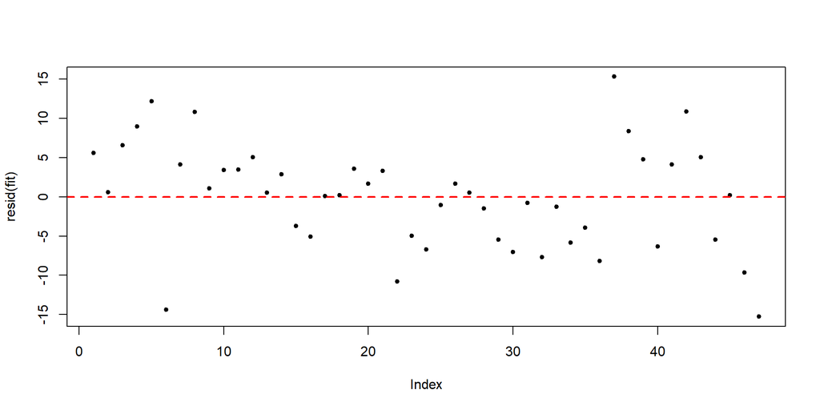

```r
plot(resid(fit),cex=1,pch=20)
abline(h=0,lwd=2,lty=2,col="red")
```

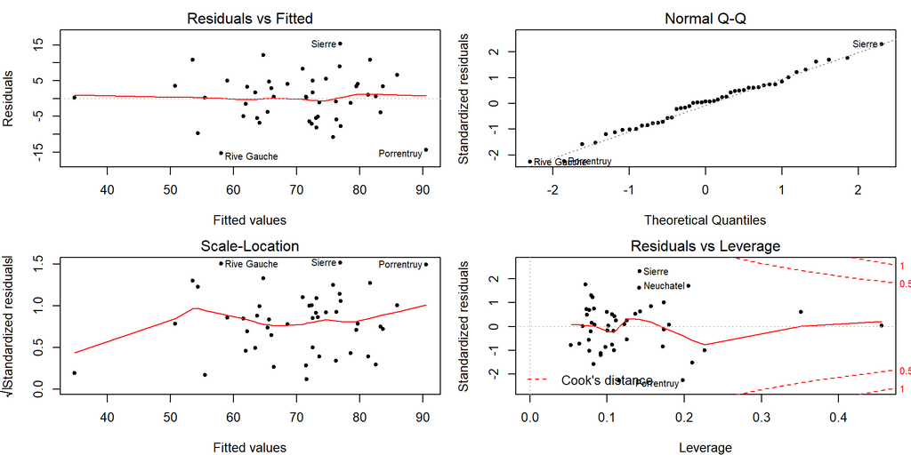

```r
#Diagnostic plots
par(mfrow=c(2,2),mar=c(4,4,2,1))
plot(fit,cex=1,pch=20)
```

## Generalized Linear Models (GLM)

- Introduced in a 1972 RSSB paper by Nelder and Werdderburn. GLMs involve three components.
1. An exponential family model for the response.
2. A systematic component via a linear predictor.
3. A link function that connects the means of the response to the linear predictor.
- The three most famous cases of GLMs are;
1. Linear models
2. Binomial and binary regression
3. Poisson regression

## Linear models (drawbacks)

- Transformations are often hard to interpret.
- There is value in modelling the data on the scale that it was collected.
- Particularly interpretable transformations, natural logarithms in specific, aren’t applicable for negative or zero values.